# Mini-Project 2

Sneha, Pema, Tenzin

October 31, 2017

## The Incumbent Advantage

Before we begin let us define some basic terms:

**Who is the ‘incumbent’?**

*The ‘incumbent’ is the current holder of an office or a political post.*

**Who is the ‘challenger’?**

*The ‘challenger’ is the person who wants to hold the office or political post next, i.e the person challenging the incumbent.*

*For example, in the 2012 U.S. presidential elections, Mitt Romney was challenger to Barack Obama’s incumbency.*

**What is an ’Open Seat?**

*An election with no incumbent runner is called an open seat.*

**What is the Incumbent Advantage?**

As the incumbent, one holds many advantages over the challenger. Some of these advantages come in the form of:

- Funding
- Name recognition
- National attention
- Fundraising and Campaign Bases
- Control over the instruments of govt.
- Successful Campaign Experience
- Presumption of success and voters

For our project we are looking at whether incumbents held a monetary advantage over their challengers in the U.S. elections for 2012. In order to do this we will take a look at monetary contributions by committees to challengers, incumbents, and open office by state. More specifically we will be looking at transactions of type ‘24E’, i.e. transactions made to advocate the election of a candidate.

```r
library(tidyverse)
library(lubridate)
```

```r
head(house_elections)
head(committees)
head(contributions)
```

[output not shown]

```r
candidate_contributions <- candidates %>%
  #joining candidates and contributions by "cand_id"
  inner_join(contributions, by = "cand_id") %>%
  #selecting the relevant variables
  select(cand_id, cand_name, cand_ici, cand_election_yr, cand_party_affiliation, cmte_id, transaction_type, name, transaction_dt, transaction_amt, state)
```

```r
committee_to_cand <- candidate_contributions %>%
  #joining candidates, committees and contributions
  inner_join(committees, by = "cmte_id") %>%
  #select relevant columns
  select(cmte_id, cmte_name, cmte_party_affiliation, transaction_type, name, transaction_dt, transaction_amt, cand_name, cand_party_affiliation, cand_ici, state)
```

```r
#set the desired values of transaction_type
#transaction <- c("24A", "24E")
transaction <- c("24E") #look for transactions advocating election of a candidate
committee_to_cand <- committee_to_cand %>%
  #filter transaction_type to values in 'transaction' i.e either "24A" or "24E"
  filter(transaction_type %in% transaction) %>%
  mutate(transaction_dt = mdy(transaction_dt))
```

```r
#filter date to year 2012 i.e transactions between Jan 1st, 2012 to Dec 31st, 2012
committee_trans_2012 <- committee_to_cand %>%
  filter(transaction_dt >= "2012-01-01" & transaction_dt <= "2012-12-31")
head(committee_trans_2012)
```

```
## # A tibble: 6 x 11
##     cmte_id                                cmte_name
##       <chr>                                    <chr>
## 1 C00332296 SUSAN B ANTHONY LIST INC. CANDIDATE FUND
## 2 C00332296 SUSAN B ANTHONY LIST INC. CANDIDATE FUND
## 3 C00332296 SUSAN B ANTHONY LIST INC. CANDIDATE FUND
## 4 C90011313                 SUSAN B ANTHONY LIST INC
## 5 C90011313                 SUSAN B ANTHONY LIST INC
## 6 C00332296 SUSAN B ANTHONY LIST INC. CANDIDATE FUND
## # ... with 9 more variables: cmte_party_affiliation <chr>,
## #   transaction_type <chr>, name <chr>, transaction_dt <date>,
## #   transaction_amt <dbl>, cand_name <chr>, cand_party_affiliation <chr>,
## #   cand_ici <chr>, state <chr>
```

```r
unique(committee_trans_2012$cmte_name)[c(1,2,3,4,5,6)]
```

```
## [1] "SUSAN B ANTHONY LIST INC. CANDIDATE FUND"
## [2] "SUSAN B ANTHONY LIST INC"
## [3] "AMERICAN ACTION NETWORK INC"
## [4] "CLUB FOR GROWTH PAC"
## [5] "NATIONAL RIFLE ASSOCIATION OF AMERICA POLITICAL VICTORY FUND"
## [6] "NATIONAL RIGHT TO LIFE POLITICAL ACTION COMMITTEE"
```

*Let us begin by looking at the contributions made by a single committee - the “Susan B Anthony List Ince. Candidate Fund”*

```r
susanb_cand_fund <- committee_trans_2012 %>%
  #filtered for a certain committee
  filter(cmte_name == "SUSAN B ANTHONY LIST INC. CANDIDATE FUND") %>%
  #grouped by whether candidate is incumbent, challenger or
  group_by(cmte_name, cand_ici, state) %>%
  summarise(cont_to_ici = sum(transaction_amt, na.rm = TRUE))

committee_summary <- function(data_trans, cmt_name)
  data_trans %>%
    #filtered for a certain committee
    filter(cmte_name == cmt_name) %>%
    #grouped by whether candidate is incumbent, challenger or
    group_by(cmte_name, cand_ici) %>%
    summarise(cont_to_ici = sum(transaction_amt, na.rm = TRUE))
```

```r
#global variables that can be accessed by all functions and plots
col1 <- "#EBDF8E"
col2 <- "#EFC1CF"
col3 <- "#83C6CC"
font <- "sans"
```

[figure not shown]

[figure not shown]

[figure not shown]

```r
plot_cmt_summary <- function(cmt_summary,cmt_name)
  ggplot(cmt_summary, aes(x = cmte_name, y = cont_to_ici,
                          fill = cand_ici))+
  coord_flip() +
  geom_bar(stat = "identity") +
  scale_x_discrete("Committee", labels = c(cmt_name)) +
  scale_y_continuous("Total Contributions", limits = c(0,sum(cmt_summary$cont_to_ici)), breaks = seq(0,sum(cmt_summary$cont_to_ici), sum(cmt_summary$cont_to_ici)/5), labels = c("0%","20%","40%","60%","80%","100%") ) +
  scale_fill_manual(values = c("#999999", "#E69F00", "#56B4E9"),
                    name = "Candidate\nStatus",
                    breaks = c("C", "I", "O"),
                    labels = c("Challenger", "Incubent", "Open Office"))

#  theme(plot.title = element_text(lineheight=.8, face="bold", family = font),
#       axis.title.x = element_text(size = 9, face = "bold", family = font),
#      axis.title.y = element_text(size = 9, face = "bold", family = font),
#     legend.position = "bottom",
#    legend.title = element_text(size = 9, face = "bold"))
#  guides(fill = guide_legend("Candidate
#Status"))
```

```r
#function:
contributions <- function(com_name) {
  table <- committee_trans_2012 %>%
  #filtered for a certain committee
  filter(cmte_name == com_name) %>%
  #grouped by whether candidate is incumbent, challenger or
  group_by(cmte_name, cand_ici, state) %>%
  summarise(cont_to_ici = sum(transaction_amt, na.rm = TRUE))
head(table)

ggplot(table, aes(x = state, y = cont_to_ici,
                             fill = cand_ici))+
  coord_flip()+
  ggtitle(com_name)+
  geom_bar(stat = "identity") +
  geom_text(aes(label=cont_to_ici),position=position_stack(vjust=0.5))+
  scale_x_discrete("State") +
  scale_y_continuous("Total '24E' Contributions:\n Transaactions Advocating Election of a Candidate", limits = c(0,10000), breaks = seq(0, 10000, 5000), labels = c("$0", "$5,000", "$10,000")) +
  scale_fill_manual(values = c(col1, col2, col3),
                    name = "Candidate\nStatus",
                    breaks = c("C", "I", "O"),
                    labels = c("Challenger", "Incubent", "Open Office"))+
  theme(plot.title = element_text(lineheight=.8, face="bold", family = font),
        axis.title.x = element_text(size = 9, face = "bold", family = font),
        axis.title.y = element_text(size = 9, face = "bold", family = font),
        legend.position = "bottom",
        legend.title = element_text(size = 9, face = "bold"))
}
```

```r
com_name <- c("SUSAN B ANTHONY LIST INC. CANDIDATE FUND", "CLUB FOR GROWTH PAC", "SUSAN B ANTHONY LIST INC", "NATIONAL RIFLE ASSOCIATION OF AMERICA POLITICAL VICTORY FUND")
```

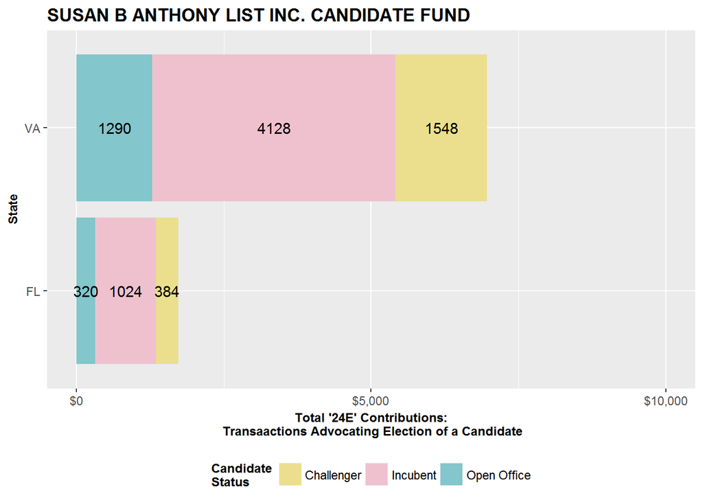

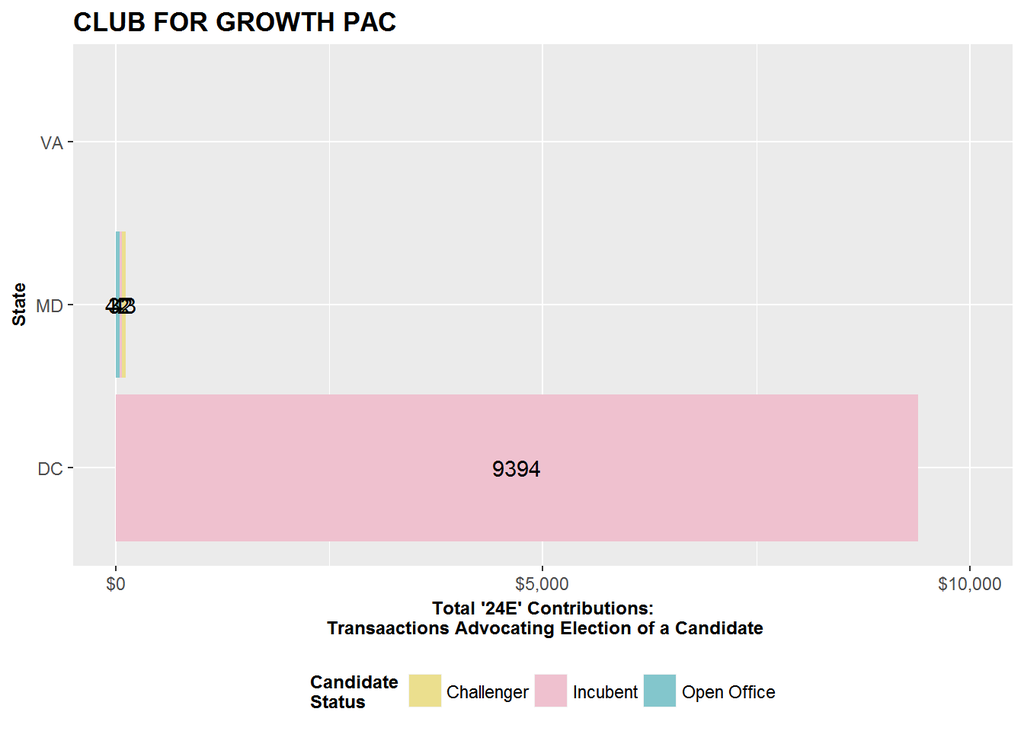

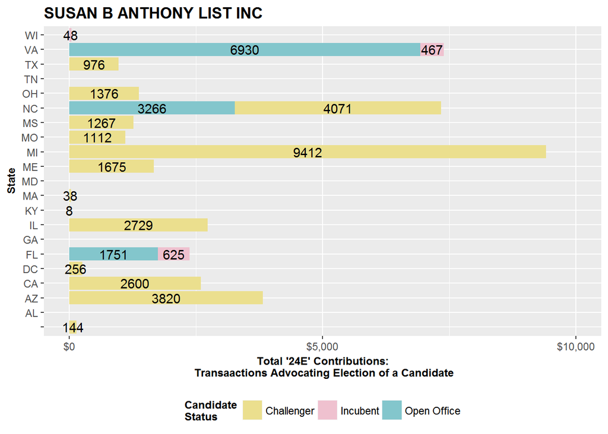

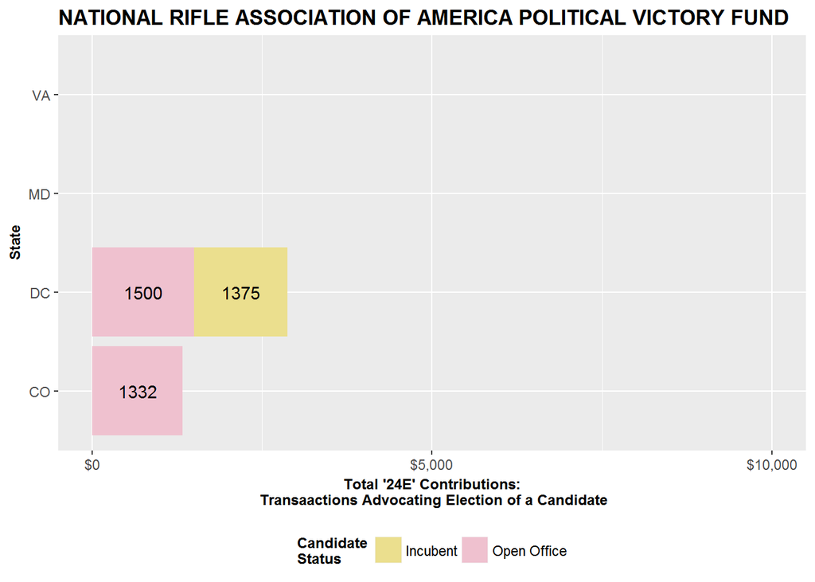

```r
lapply(com_name, FUN = contributions)
```